# XGBoost on Forest Fires

Used the resources provided and my own knowledge:  
https://www.projectpro.io/recipes/apply-xgboost-r-for-regression/  
https://www.r-bloggers.com/2020/11/r-xgboost-regression/  
https://www.nvidia.com/en-us/glossary/data-science/xgboost/

## Start

### Loading Libraries and Data

```r
# load packages
# https://stackoverflow.com/questions/18931006/how-to-suppress-warning-messages-when-loading-a-library
suppressWarnings(library(tidyverse)) #for ggplot and dplyr
library(corrplot) #for correlation plots
library(rattle)
library(caTools)
library(xgboost)
library(caret)
```

```r
setwd("C:/Users/ezhou/OneDrive - Eastside Preparatory School/Documents/Eric/2022 - 2023/1 Fall/A Data Science/Forest Fires")
forestRaw <- read.csv("forestfires.csv")
```

### Data Preprocessing

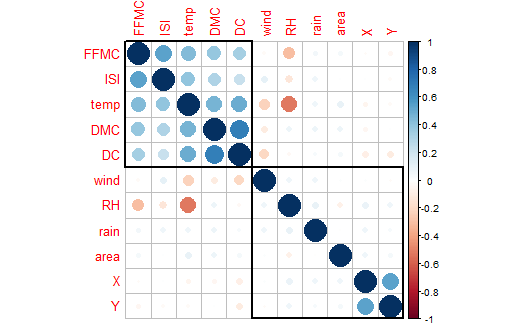

```r
# summary(forestRaw)

forestNum <- forestRaw %>% select(-month, -day)
corrs <- cor(forestNum)
corrplot(corrs, order = 'hclust', addrect = 2)
```

```r
# RMSE function
myRMSE <- function(pred, obs) {
  return(sqrt(mean((pred - obs) ^ 2, na.rm = TRUE)))
}
```

```r
forestNum <- forestNum %>% mutate(logArea = log(area+1))
# summary(forestNum)
```

## XGBoost

XGBoost stands for extreme gradient boosting. Boosting is the improvement of a weak model by combining it with many other weak models. Gradient boosting is an extension of that where the process of generating other weak models formalized as a gradient descent algorithm tuning for a certain objective. XGBoost is extreme because it uses multithreading and pushes the limits of the computer’s computing power. XGBoost also does regularization and uses both trees and linear models.

### Splitting Data

```r
set.seed(49301) # keeping the same seed as the other file
ind <- sample.split(Y=forestNum, SplitRatio=0.8)
trainData <- forestNum[ind,]
testData <- forestNum[-ind,]
# head(trainData)

train_x = data.matrix(trainData[,-11:-12])
train_y = trainData[,12]
# head(train_x)
# head(train_y)

test_x = data.matrix(testData[,-11:-12])
test_y = testData[,12]

xgb_train = xgb.DMatrix(data = train_x, label = train_y)
xgb_test = xgb.DMatrix(data = test_x, label = test_y)
```

### Creating Model

```r
watchlist = list(train=xgb_train, test=xgb_test)
start <- Sys.time()
model = xgb.train(data = xgb_train, max.depth = 3, watchlist=watchlist, nrounds = 1000, verbose=FALSE, early_stopping_rounds = 10)
end <- Sys.time()
(time <- end - start)
pred_y = predict(model, xgb_test)
myRMSE(pred_y, test_y)
```

[output not shown]

Model is a bit slower, took around 1 second. The error for 100 rounds is around 0.94 (close to random forest), but 1000 makes it around 0.86, which is a lot better.

```r
imp_mat <- xgb.importance(model = model)
xgb.plot.importance(imp_mat, xlab = "Feature Importance")
```

[output not shown]

The feature importance matches pretty well with what we saw last time with the randomForest. Temperature is still way above and rain is still dead last. The order in the middle are slightly different but they all remain decently close and close to the spots from before.

### Grid Search Tuning of Max_Depth and ETA

```r
set.seed(49301)
start <- Sys.time()
hyper_grid <- expand.grid(max_depth = seq(2, 10, 1), eta = seq(0, .35, .01))
xgb_train_rmse <- NULL
xgb_test_rmse <- NULL

for (j in 1:nrow(hyper_grid)) {
  m_xgb_untuned <- xgb.cv(
    data = train_x,
    label = train_y,
    nrounds = 1000,
    objective = "reg:squarederror",
    early_stopping_rounds = 5,
    nfold = 5,
    max_depth = hyper_grid$max_depth[j],
    eta = hyper_grid$eta[j],
    verbose = FALSE,
    nthreads = 6
  )
  xgb_train_rmse[j] <- m_xgb_untuned$evaluation_log$train_rmse_mean[m_xgb_untuned$best_iteration]
  xgb_test_rmse[j] <- m_xgb_untuned$evaluation_log$test_rmse_mean[m_xgb_untuned$best_iteration]
}

hyper_grid[which.min(xgb_train_rmse),]
end <- Sys.time()
(time <- end - start)
```

[output not shown]

Through trying every combination with in the range, we find that 6 and 0.34 for max_depth and eta respectively got the lowest training RMSE. I tried using testing RMSE earlier and it did not work at all so I decided to just find the minimum training RMSE instead and it seems to work a lot better. Tuning does take a whole 2 minutes though but it makes sense since it’s running through every combination possible.

```r
start <- Sys.time()
model2 = xgb.train(data = xgb_train, max.depth = 6, eta = 0.34, watchlist=watchlist, nrounds = 1000, verbose=FALSE, early_stopping_rounds = 10)
end <- Sys.time()
(time <- end - start)
pred_y2 = predict(model2, xgb_test)
myRMSE(pred_y2, test_y)
```

[output not shown]

Making the XGBoost model is very fast, <0.6 seconds. The RMSE after tuning is a bit better, dropping from ~0.86 to ~0.81.

```r
imp_mat <- xgb.importance(model = model2)
xgb.plot.importance(imp_mat, xlab = "Feature Importance")
```

[output not shown]

### Tuning the nrounds

```r
set.seed(49301)
start <- Sys.time()
rounds <- expand.grid(rs = seq(100, 10000, 100))
xgb_train_rmse <- NULL
xgb_test_rmse <- NULL

for (j in 1:nrow(rounds)) {
  m_xgb_untuned <- xgb.cv(
    data = train_x,
    label = train_y,
    nrounds = rounds$rs[j],
    objective = "reg:squarederror",
    early_stopping_rounds = 5,
    nfold = 5,
    max_depth = 6,
    eta = 0.34,
    verbose = FALSE
  )
  # print(rounds$rs[j])
  xgb_train_rmse[j] <- m_xgb_untuned$evaluation_log$train_rmse_mean[m_xgb_untuned$best_iteration]
  xgb_test_rmse[j] <- m_xgb_untuned$evaluation_log$test_rmse_mean[m_xgb_untuned$best_iteration]
}

rounds[which.min(xgb_train_rmse),]
rounds[which.min(xgb_test_rmse),]
rounds$rmse = xgb_train_rmse
ggplot(rounds) +
  geom_point(aes(x=rs, y = xgb_test_rmse)) +
  ggtitle("RMSE as nrounds Varies")
end <- Sys.time()
(time <- end - start)
```

[output not shown]

The graph seems pretty chaotic and the points are pretty much concentrated in one area with a few outliers.

```r
start <- Sys.time()
model3 = xgb.train(data = xgb_train, max.depth = 6, eta = 0.34, watchlist=watchlist, nrounds = 1, verbose=FALSE, early_stopping_rounds = 10)
model4 = xgb.train(data = xgb_train, max.depth = 6, eta = 0.34, watchlist=watchlist, nrounds = 10, verbose=FALSE, early_stopping_rounds = 10)
model5 = xgb.train(data = xgb_train, max.depth = 6, eta = 0.34, watchlist=watchlist, nrounds = 100, verbose=FALSE, early_stopping_rounds = 10)
model6 = xgb.train(data = xgb_train, max.depth = 6, eta = 0.34, watchlist=watchlist, nrounds = 4900, verbose=FALSE, early_stopping_rounds = 10)
model7 = xgb.train(data = xgb_train, max.depth = 6, eta = 0.34, watchlist=watchlist, nrounds = 9600, verbose=FALSE, early_stopping_rounds = 10)
end <- Sys.time()
(time <- end - start)
pred_y3 = predict(model3, xgb_test)
pred_y4 = predict(model4, xgb_test)
pred_y5 = predict(model5, xgb_test)
pred_y6 = predict(model6, xgb_test)
pred_y7 = predict(model7, xgb_test)
myRMSE(pred_y3, test_y)
myRMSE(pred_y4, test_y)
myRMSE(pred_y5, test_y)
myRMSE(pred_y6, test_y)
myRMSE(pred_y7, test_y)
```

[output not shown]

It seems like the nrounds doesn’t matter too much after tuning eta and max.depth. When I ran the model before tuning, nrounds at 100 performed a lot worse than 1000. However, now there is no difference between 100 and 4900.

## Comparison

```r
myRMSE(pred_y5, test_y)
```

Based on overall RMSE, my best decision tree got to ~1.33 and my best random forest was at ~0.93. The tuned XGBoost model did a lot better, getting all the way down to ~0.81. As for benefits, decision tree is the simplest of the bunch so it is a lot faster to train but loses accuracy. Random forest is a bit more complex and does prevent overfitting but still does not reach the level of XGBoost. XGBoost takes the most time to train and has a myriad of variables to tune but does offer the best accuracy. It also fits different forms of data and minimizes underfitting.

```r
model8 = xgb.train(data = xgb_train, max.depth = 6, eta = 0.34, watchlist=watchlist, nrounds = 60, verbose=FALSE, early_stopping_rounds=10, alpha=0, lambda=0.001)
pred_y8 = predict(model8, xgb_test)
myRMSE(pred_y8, test_y)
```